# Steps for building models

# Steps for Design and Implement your model

- Design conceptual model
- Translate conceptual model into a mathematical representation
- Choose programming language
- Define inputs (data type, units)
- Define output (data type, units)
- Define model structure
- Write model
- Document the model (meta data)
- Test model

# Modularity - Discrete Tasks

Hierarchical in level of details

Big chunks (coarse detail) -> progressively finer

Note ‘tasks’ that need to be repeated

All tasks should have inputs and outputs

# From conceptual model to flow chart/workflow

Impact of climate on almond productivity

What is almond productivity?

What is climate?

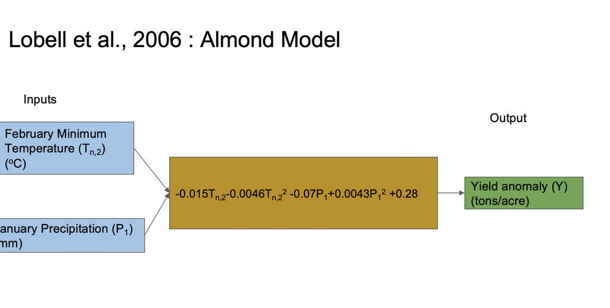

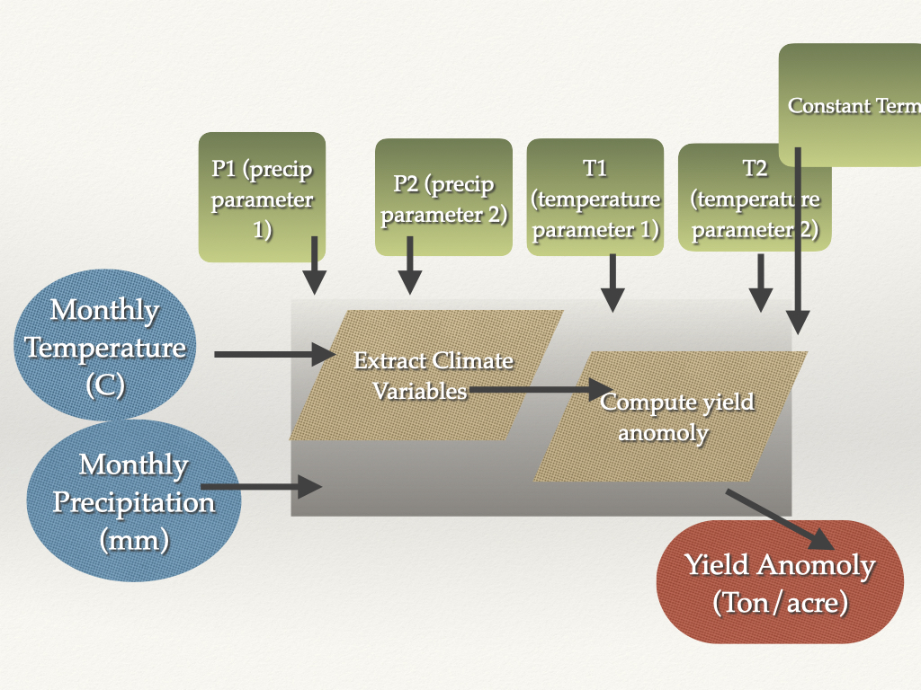

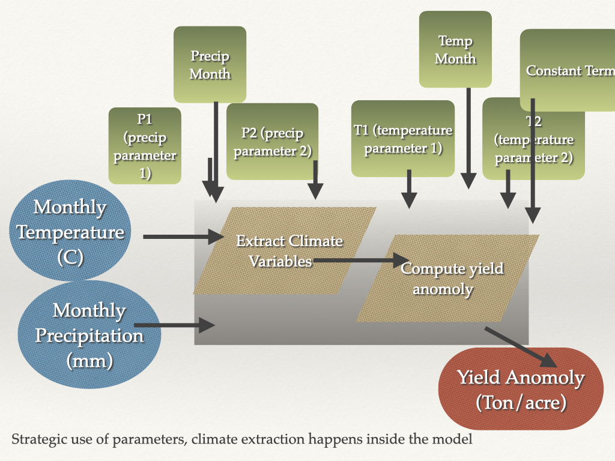

# Building Models

Functions!

The basic building blocks of models

Functions can be written in all languages; in many languages (object-oriented) like C++, Python, functions are also objects

Functions are the “boxes” of the model - the transfer function that takes inputs and returns outputs

More complex models - made up of multiple functions; and nested functions (and main functions that call/user other functions and control the flow - the arrows between boxes)

# Functions

Decide on

- Inputs and parameters
- Outputs

Data types, units (time and space aggregation), names should be (use descriptive names)

# Functions

## Simple

- input (mean growing season temperature - growT);
- parameter (senT - sensitivity to temperature
- output (growth )

(all float)

## More complex

- inputs (temperature (growT), Plant type)
- parameters
  - sensT (array of temperature sensitivities for different plant types),
  - growingmonths (array of growing season months for differnt plant types)
- output ( growth)

**IMPORTANT**

## Place each function in its own file (x.R), and put all functions for a given project in *R* subdirectory

# Example

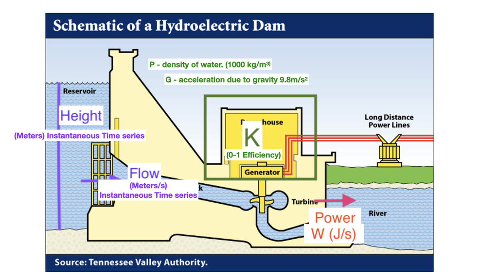

- Input: Reservoir height (height) and flow rate (flow)
- Output: Instantaneous power generation (W/s)
- Parameters: K Efficiency , ρ (density of water), g (acceleration due to gravity)

P = ρ * h * r * g * K Efficiency;

P is Power in watts, ρ is the density of water (~1000 kg/m3), h is height in meters, r is flow rate in cubic meters per second, g is acceleration due to gravity of 9.8 m/s2, K Efficiency is a coefficient of efficiency ranging from 0 to 1.

This is a static (one point in time), deterministic, lumped (one place) model; its more or less physically based

# Building Models

Inputs/parameters are height, flow, rho, g, and K

For some (particularly parameters) we provide default values by assigning them a value (e.g Keff = 0.8), but we can overwrite these

Body is the equations between { and } *return* tells R what the output is

```r
library(tidyverse)
power_gen = function(height, flow, rho=1000, g=9.8, Keff=0.8) {

result = rho * height * flow * g * Keff
return(result)
}

power_gen(height=10, flow=2)
```

```
## [1] 156800
```

```r
power_gen(10,2)
```

```
## [1] 156800
```

```r
power_gen(10,2, g=4.2)
```

```
## [1] 67200
```

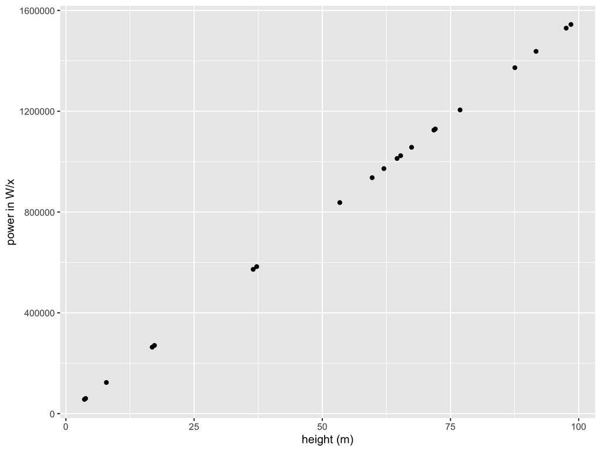

```r
# generate some test data
measured_height=runif(min=1, max=100, n=20)

# create a data frame to store results of model run
power_estimate = cbind.data.frame(height=measured_height, estimate=power_gen(height=measured_height, flow=2))

# graph
ggplot(power_estimate,aes(height, estimate) )+geom_point()+labs(y="power in W/x", x="height (m)")
```

```r
#' Power Generation
#'
#' This function computes instantaneous power generation
#’ from a reservoir given its height and flow rate into turbines
#' @param rho Density of water (kg/m3) Default is 1000
#' @param g Acceleration due to gravity (m/sec2) Default is 9.8
#' @param Kefficiency Turbine Efficiency (0-1) Default is 0.8
#' @param height height of water in reservoir (m)
#' @param flow flow rate (m3/sec)
#' @author Naomi
#' @examples power_gen(20, 1)
#' @return Power generation (W/s)


power_gen = function(height, flow, rho=1000, g=9.8, Keff=0.8) {



  # calculate power
    result = rho * height * (flow) * g * Keff


  return(result)
}
```

# Sharing Example R, Data and Rmarkdowns

[esm232_examples github site]{https://github.com/naomitague/ESM232_Examples.git}

You can clone this repository and then pull before class to get example code and data

Just remember that git does not like having nest repositories - so keep working respoistories in separate directories